# Simple Linear Regression: Residual Analysis

Roxana Butenco

7/6/2019

In order to see how good the model we have produced fits the data, we will perform residual analysis for each of the predictors individually. This will help us see how is our error: is our error large oris it small. It will also tell us whether the model we are using is actually apropriate for our data.  
In fact, residuals are useful to identifying potential problems of any statistical model. For example, the residuals from a linear regression model should be homoscedastic (same variance). Otherwise, this indicates an issue with the model such as non-linearity in the data.

```r
setwd("~/RDemo/BostonRegression")
# read in data from a csv file
Boston = read.csv(file="Boston.csv",header=TRUE,sep=",")
attach(Boston)
```

## Step 1: Fit the model

```r
dataset <- Boston
fit <- lm(crim ~ zn, data = dataset)
summary(fit)
```

```
##
## Call:
## lm(formula = crim ~ zn, data = dataset)
##
## Residuals:
##    Min     1Q Median     3Q    Max
## -4.429 -4.222 -2.620  1.250 84.523
##
## Coefficients:
##             Estimate Std. Error t value Pr(>|t|)
## (Intercept)  4.45369    0.41722  10.675  < 2e-16 ***
## zn          -0.07393    0.01609  -4.594 5.51e-06 ***
## ---
## Signif. codes:  0 '***' 0.001 '**' 0.01 '*' 0.05 '.' 0.1 ' ' 1
##
## Residual standard error: 8.435 on 504 degrees of freedom
## Multiple R-squared:  0.04019,    Adjusted R-squared:  0.03828
## F-statistic:  21.1 on 1 and 504 DF,  p-value: 5.506e-06
```

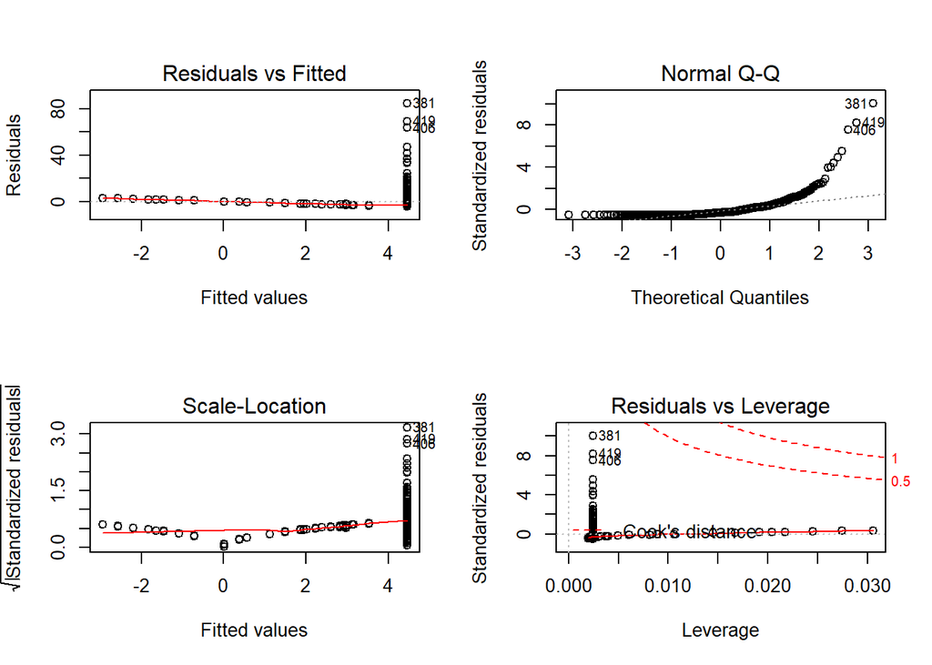

```r
par(mfrow = c(2, 2))
plot(fit)  # Plot the model and the residuals in the traditional R way
```

## Step 2: Obtain predicted and residual values

```r
dataset$predicted <- predict(fit)   # Save the predicted values
dataset$residuals <- residuals(fit) # Save the residual values
# Quick look at the actual, predicted, and residual values, showing the first 6
library(dplyr)
dataset %>% select(crim, predicted, residuals) %>% head()
```

```
##      crim predicted residuals
## 1 0.00632  3.122864 -3.116544
## 2 0.02731  4.453694 -4.426384
## 3 0.02729  4.453694 -4.426404
## 4 0.03237  4.453694 -4.421324
## 5 0.06905  4.453694 -4.384644
## 6 0.02985  4.453694 -4.423844
```

## Step 3: Plot the actual and predicted values

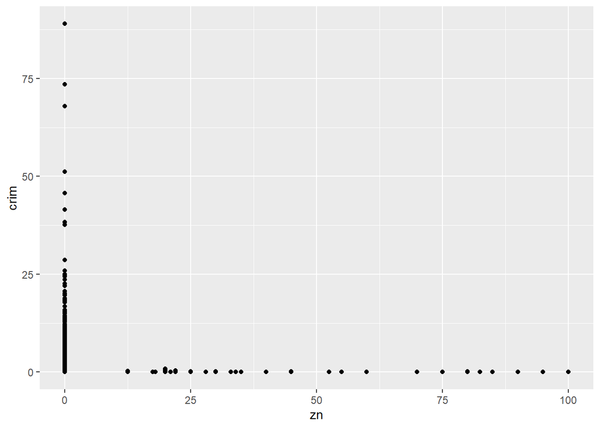

```r
library(ggplot2)
ggplot(dataset, aes(x = zn, y = crim)) +
  geom_point()  # Plot the actual points
```

Next, we plot the predicted values in a way that they’re distinguishable from the actual values.

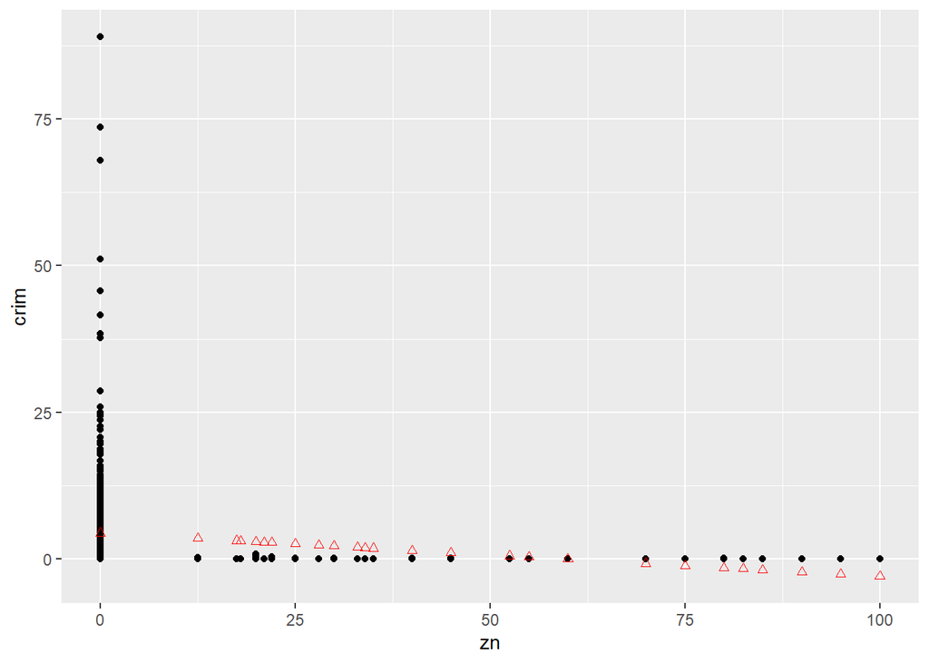

```r
ggplot(dataset, aes(x = zn, y = crim)) +
  geom_point() +
  geom_point(aes(y = predicted), shape = 2, color = "red")  # Add the predicted values and change their shape
```

Connect the actual data points with their corresponding predicted value

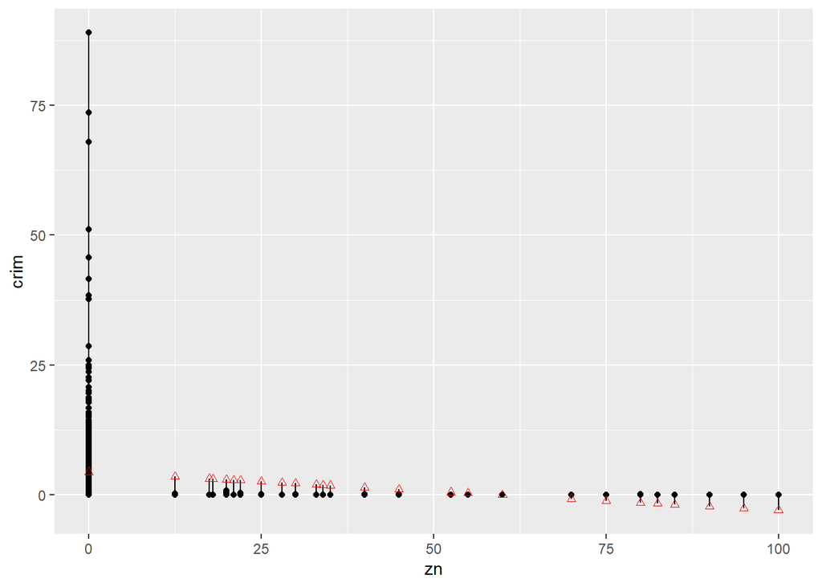

```r
ggplot(dataset, aes(x = zn, y = crim)) +
  geom_segment(aes(xend = zn, yend = predicted)) +
  geom_point()+
  geom_point(aes(y = predicted), shape = 2, color = "red")
```

Add the regression slope with geom_smooth():

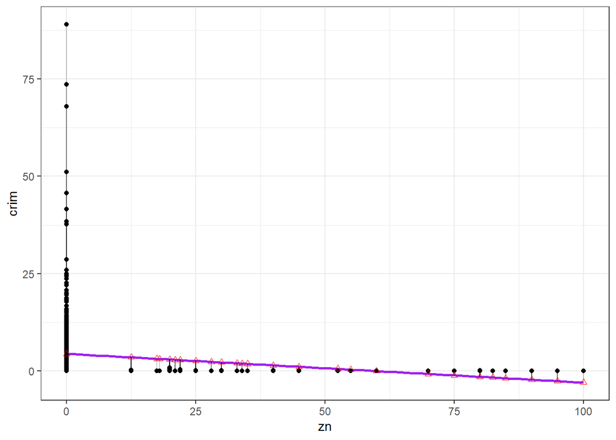

```r
ggplot(dataset, aes(x = zn, y = crim)) +
  geom_smooth(method = "lm", se = FALSE, color = "purple") +  # Plot regression slope
  geom_segment(aes(xend = zn, yend = predicted), alpha = .2) +  # alpha to fade lines
  geom_point() +
  geom_point(aes(y = predicted), shape = 2, color = "red") +
  theme_bw()
```

## Step 4: Use residuals to adjust color

Different color for actual value greater or less than predicted

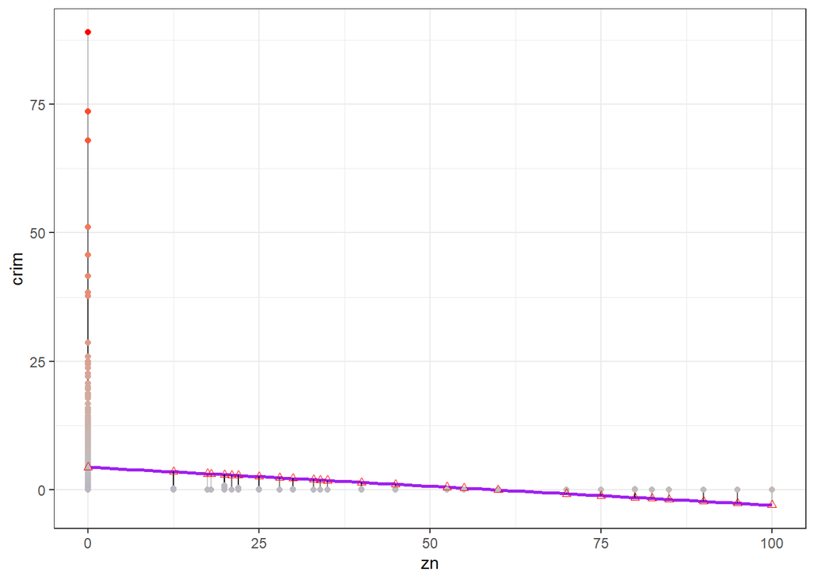

```r
ggplot(dataset, aes(x = zn, y = crim)) +
  geom_smooth(method = "lm", se = FALSE, color = "purple") +
  geom_segment(aes(xend = zn, yend = predicted), alpha = .2) +
  # > Color adjustments made here...
  geom_point(aes(color = residuals)) +  # Color mapped here
  scale_color_gradient2(low = "blue", mid = "grey", high = "red") +  # Colors to use here
  guides(color = FALSE) +
  geom_point(aes(y = predicted), shape = 2, color = "red") +
  theme_bw()
```

In this example, the colours nicely help to identify non-linearity in the data:

There is no other statistical meaningfull interpretation from this example.

Lets have a look at Crim and Age

```r
fit1 <- lm(crim ~ age, data = dataset)
summary(fit1)
```

```
##
## Call:
## lm(formula = crim ~ age, data = dataset)
##
## Residuals:
##    Min     1Q Median     3Q    Max
## -6.789 -4.257 -1.230  1.527 82.849
##
## Coefficients:
##             Estimate Std. Error t value Pr(>|t|)
## (Intercept) -3.77791    0.94398  -4.002 7.22e-05 ***
## age          0.10779    0.01274   8.463 2.85e-16 ***
## ---
## Signif. codes:  0 '***' 0.001 '**' 0.01 '*' 0.05 '.' 0.1 ' ' 1
##
## Residual standard error: 8.057 on 504 degrees of freedom
## Multiple R-squared:  0.1244, Adjusted R-squared:  0.1227
## F-statistic: 71.62 on 1 and 504 DF,  p-value: 2.855e-16
```

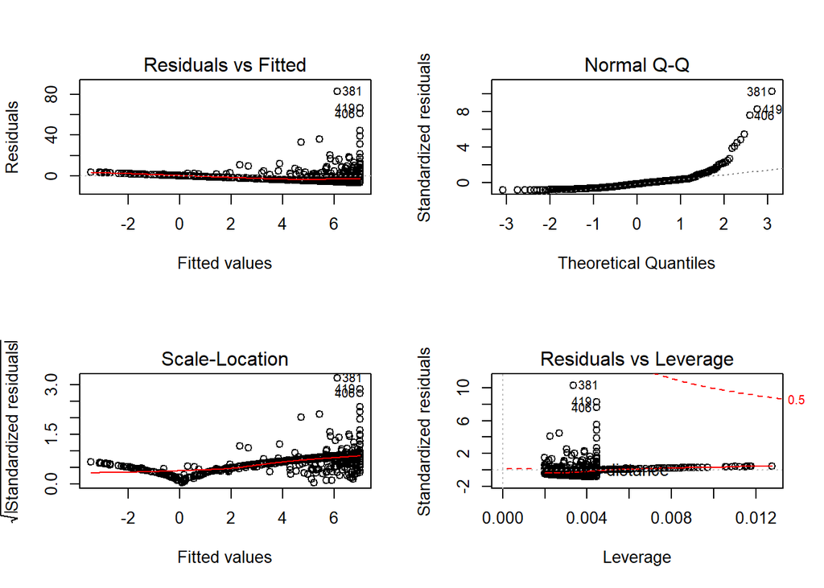

```r
par(mfrow = c(2, 2))
plot(fit1)
```

```r
dataset$predicted <- predict(fit1)   # Save the predicted values
dataset$residuals <- residuals(fit1)
dataset %>% select(crim, predicted, residuals) %>% head()
```

```
##      crim predicted residuals
## 1 0.00632  3.249755 -3.243435
## 2 0.02731  4.726427 -4.699117
## 3 0.02729  2.807832 -2.780542
## 4 0.03237  1.158703 -1.126333
## 5 0.06905  2.064107 -1.995057
## 6 0.02985  2.549145 -2.519295
```

Plot the actual and predicted values

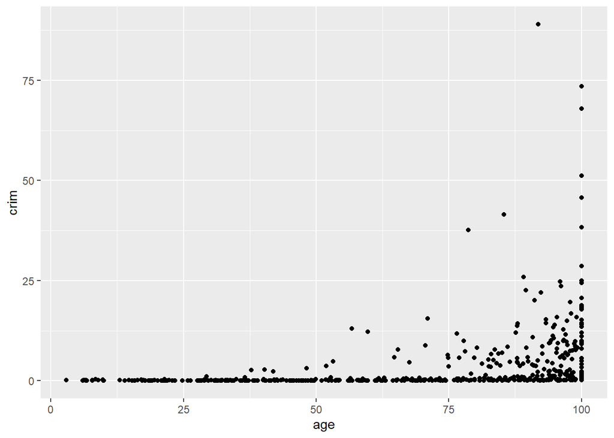

```r
ggplot(dataset, aes(x = age, y = crim)) +
  geom_point()
```

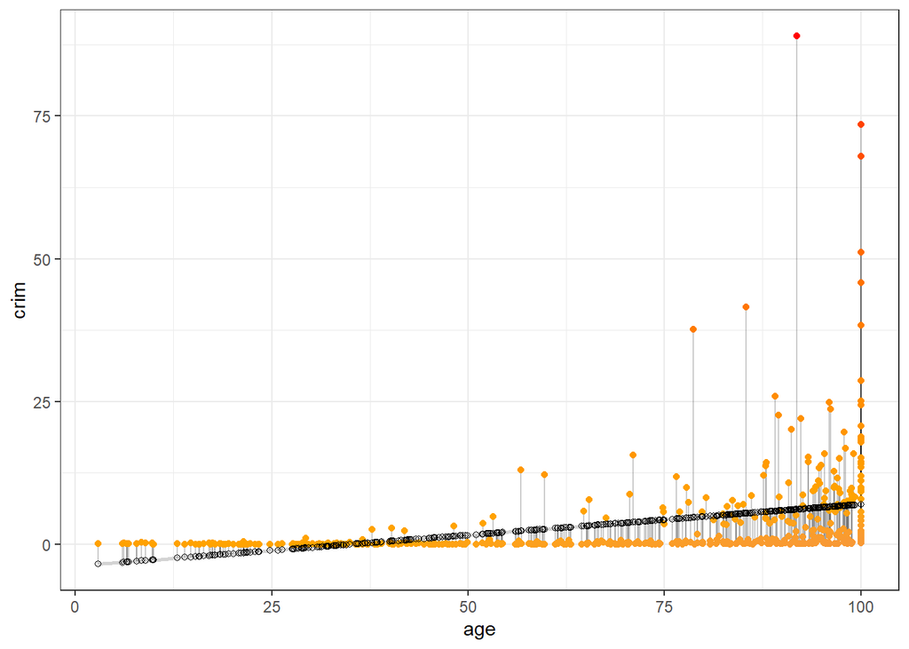

```r
ggplot(dataset, aes(x = age, y = crim)) +
  geom_smooth(method = "lm", se = FALSE, color = "lightgrey") +
  geom_segment(aes(xend = age, yend = predicted), alpha = .2) +
  geom_point(aes(color = residuals)) +  # Color mapped here
  scale_color_gradient2(low = "blue", mid = "orange", high = "red") +  # Colors to use here
  guides(color = FALSE) +
  geom_point(aes(y = predicted), shape = 1) +
  theme_bw()
```

## Residual analysis for each predictors Crim and Rad

```r
fit2 <- lm(crim ~ rad, data = dataset)
summary(fit2)
```

```
##
## Call:
## lm(formula = crim ~ rad, data = dataset)
##
## Residuals:
##     Min      1Q  Median      3Q     Max
## -10.164  -1.381  -0.141   0.660  76.433
##
## Coefficients:
##             Estimate Std. Error t value Pr(>|t|)
## (Intercept) -2.28716    0.44348  -5.157 3.61e-07 ***
## rad          0.61791    0.03433  17.998  < 2e-16 ***
## ---
## Signif. codes:  0 '***' 0.001 '**' 0.01 '*' 0.05 '.' 0.1 ' ' 1
##
## Residual standard error: 6.718 on 504 degrees of freedom
## Multiple R-squared:  0.3913, Adjusted R-squared:   0.39
## F-statistic: 323.9 on 1 and 504 DF,  p-value: < 2.2e-16
```

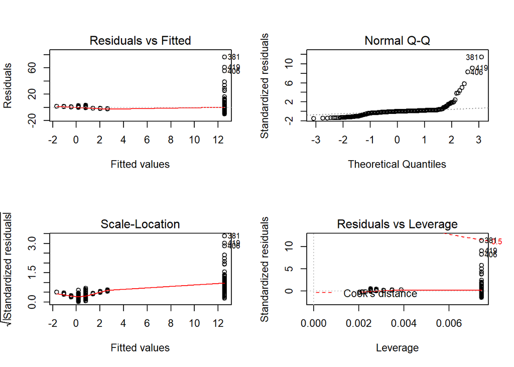

```r
par(mfrow = c(2, 2))
plot(fit2)
```

```r
dataset$predicted <- predict(fit2)
dataset$residuals <- residuals(fit2)
dataset %>% select(crim, predicted, residuals) %>% head()
```

```
##      crim  predicted residuals
## 1 0.00632 -1.6692485 1.6755685
## 2 0.02731 -1.0513376 1.0786476
## 3 0.02729 -1.0513376 1.0786276
## 4 0.03237 -0.4334267 0.4657967
## 5 0.06905 -0.4334267 0.5024767
## 6 0.02985 -0.4334267 0.4632767
```

Plot the actual and predicted values

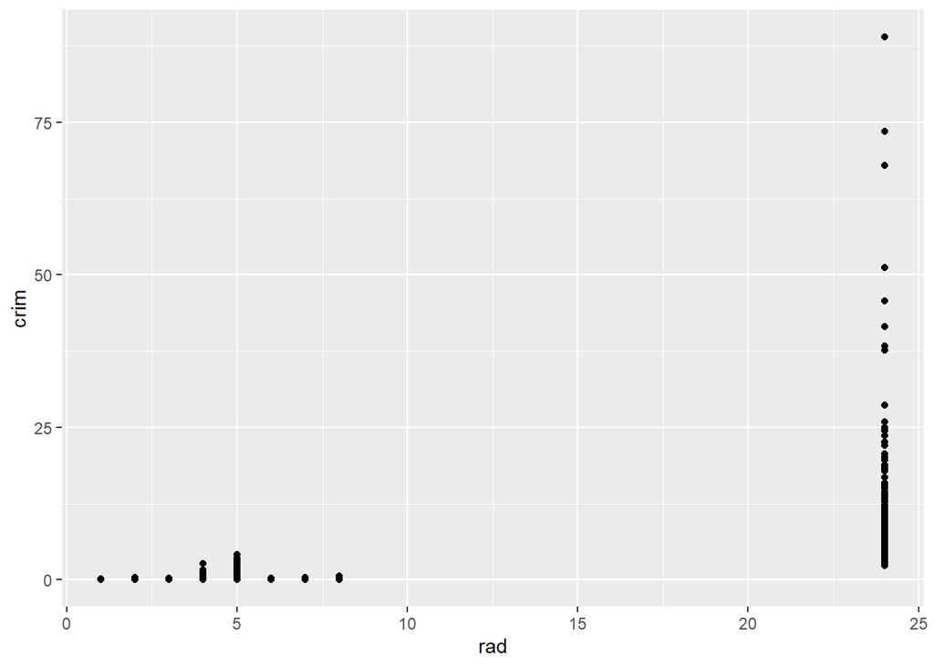

```r
ggplot(dataset, aes(x = rad, y = crim)) +
  geom_point()
```

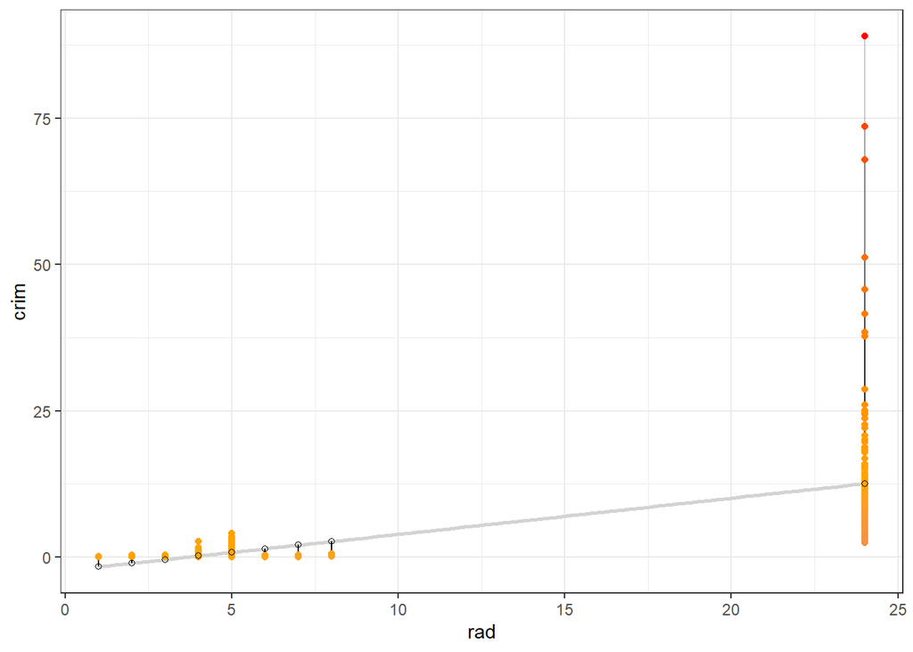

```r
ggplot(dataset, aes(x = rad, y = crim)) +
  geom_smooth(method = "lm", se = FALSE, color = "lightgrey") +
  geom_segment(aes(xend = rad, yend = predicted), alpha = .2) +
  geom_point(aes(color = residuals)) +  # Color mapped here
  scale_color_gradient2(low = "blue", mid = "orange", high = "red") +  # Colors to use here
  guides(color = FALSE) +
  geom_point(aes(y = predicted), shape = 1) +
  theme_bw()
```

Crim and Indus

```r
fit4 <- lm(crim ~ indus, data = dataset)
summary(fit4)
```

```
##
## Call:
## lm(formula = crim ~ indus, data = dataset)
##
## Residuals:
##     Min      1Q  Median      3Q     Max
## -11.972  -2.698  -0.736   0.712  81.813
##
## Coefficients:
##             Estimate Std. Error t value Pr(>|t|)
## (Intercept) -2.06374    0.66723  -3.093  0.00209 **
## indus        0.50978    0.05102   9.991  < 2e-16 ***
## ---
## Signif. codes:  0 '***' 0.001 '**' 0.01 '*' 0.05 '.' 0.1 ' ' 1
##
## Residual standard error: 7.866 on 504 degrees of freedom
## Multiple R-squared:  0.1653, Adjusted R-squared:  0.1637
## F-statistic: 99.82 on 1 and 504 DF,  p-value: < 2.2e-16
```

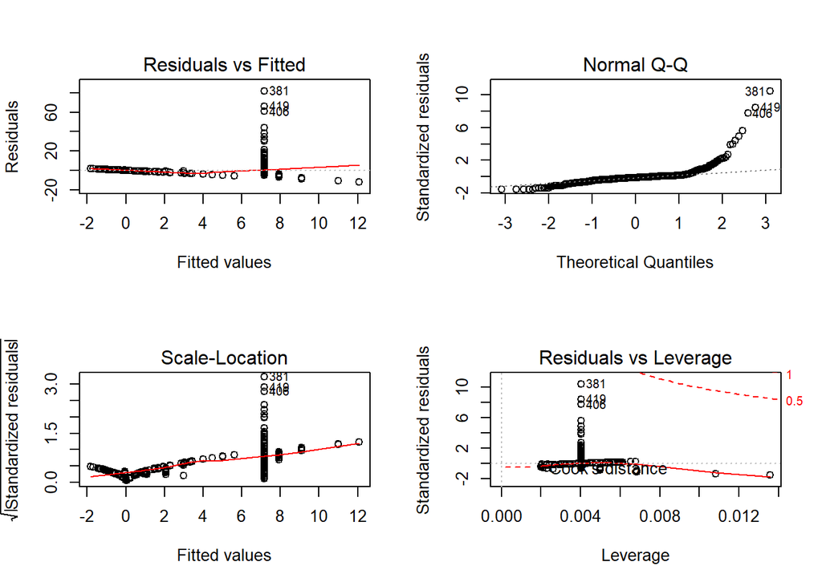

```r
par(mfrow = c(2, 2))
plot(fit4)
```

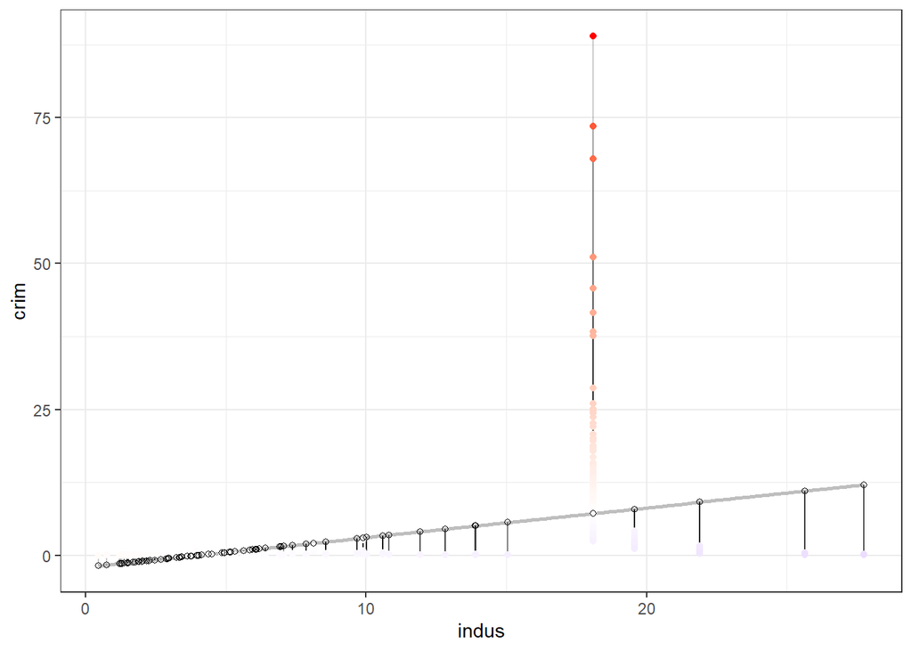

```r
dataset$predicted <- predict(fit4)
dataset$residuals <- residuals(fit4)

ggplot(dataset, aes(x = indus, y = crim)) +
  geom_smooth(method = "lm", se = FALSE, color = "grey") +
  geom_segment(aes(xend = indus, yend = predicted), alpha = .2) +
  geom_point(aes(color = residuals)) +  # Color mapped here
  scale_color_gradient2(low = "blue", mid = "white", high = "red") +  # Colors to use here
  guides(color = FALSE) +
  geom_point(aes(y = predicted), shape = 1) +
  theme_bw()
```

```r
par(mfrow = c(2, 2))
fit5 <- lm(crim ~ chas, data = dataset)
summary(fit5)
```

```
##
## Call:
## lm(formula = crim ~ chas, data = dataset)
##
## Residuals:
##    Min     1Q Median     3Q    Max
## -3.738 -3.661 -3.435  0.018 85.232
##
## Coefficients:
##             Estimate Std. Error t value Pr(>|t|)
## (Intercept)   3.7444     0.3961   9.453   <2e-16 ***
## chas         -1.8928     1.5061  -1.257    0.209
## ---
## Signif. codes:  0 '***' 0.001 '**' 0.01 '*' 0.05 '.' 0.1 ' ' 1
##
## Residual standard error: 8.597 on 504 degrees of freedom
## Multiple R-squared:  0.003124,   Adjusted R-squared:  0.001146
## F-statistic: 1.579 on 1 and 504 DF,  p-value: 0.2094
```

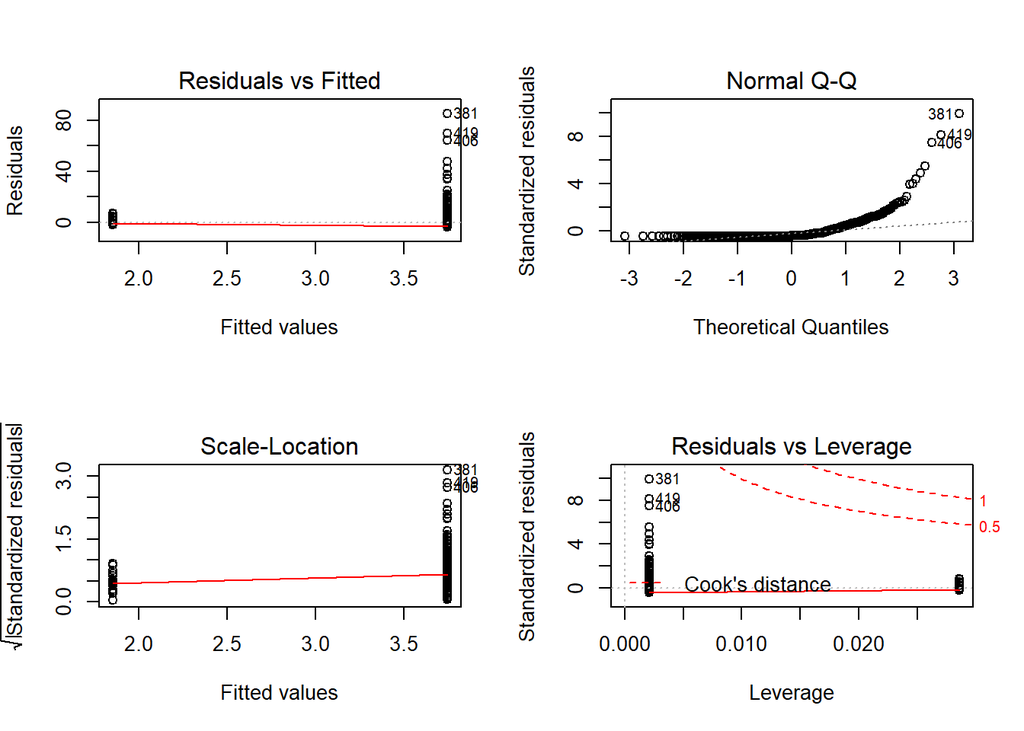

```r
plot(fit5)
```

```r
dataset$predicted <- predict(fit5)
dataset$residuals <- residuals(fit5)
```

```r
par(mfrow = c(2, 2))
fit6 <- lm(crim ~ nox, data = dataset)
summary(fit6)
```

```
##
## Call:
## lm(formula = crim ~ nox, data = dataset)
##
## Residuals:
##     Min      1Q  Median      3Q     Max
## -12.371  -2.738  -0.974   0.559  81.728
##
## Coefficients:
##             Estimate Std. Error t value Pr(>|t|)
## (Intercept)  -13.720      1.699  -8.073 5.08e-15 ***
## nox           31.249      2.999  10.419  < 2e-16 ***
## ---
## Signif. codes:  0 '***' 0.001 '**' 0.01 '*' 0.05 '.' 0.1 ' ' 1
##
## Residual standard error: 7.81 on 504 degrees of freedom
## Multiple R-squared:  0.1772, Adjusted R-squared:  0.1756
## F-statistic: 108.6 on 1 and 504 DF,  p-value: < 2.2e-16
```

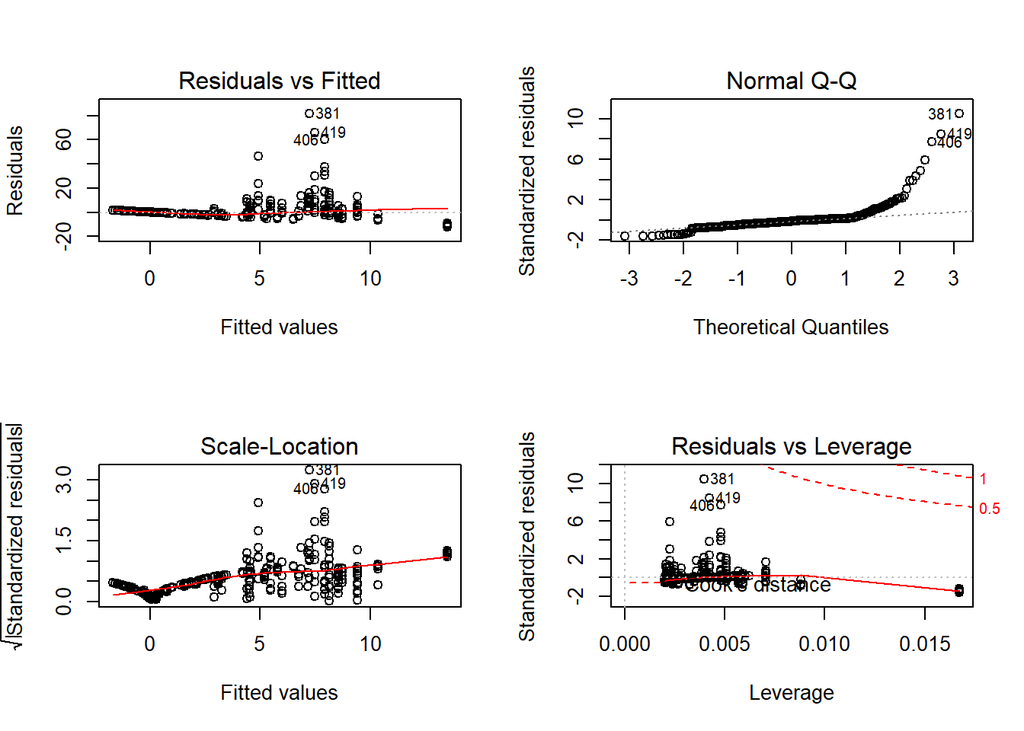

```r
plot(fit6)
```

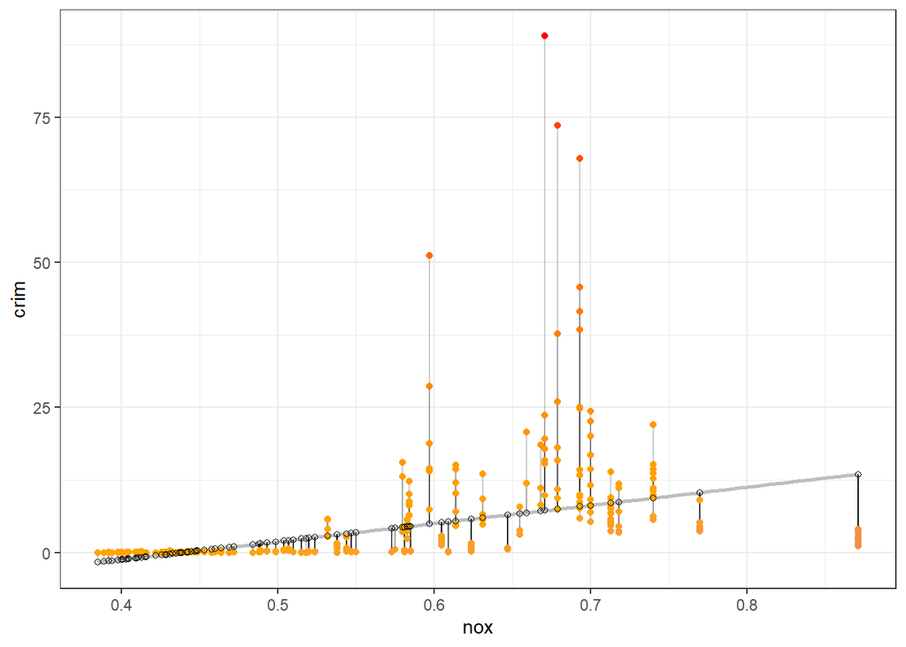

```r
dataset$predicted <- predict(fit6)
dataset$residuals <- residuals(fit6)

ggplot(dataset, aes(x = nox, y = crim)) +
  geom_smooth(method = "lm", se = FALSE, color = "grey") +
  geom_segment(aes(xend = nox, yend = predicted), alpha = .2) +
  geom_point(aes(color = residuals)) +
  scale_color_gradient2(low = "blue", mid = "orange", high = "red") +
  guides(color = FALSE) +
  geom_point(aes(y = predicted), shape = 1) +
  theme_bw()
```

```r
fit7 <- lm(crim ~ rm, data = dataset)
summary(fit7)
```

```
##
## Call:
## lm(formula = crim ~ rm, data = dataset)
##
## Residuals:
##    Min     1Q Median     3Q    Max
## -6.604 -3.952 -2.654  0.989 87.197
##
## Coefficients:
##             Estimate Std. Error t value Pr(>|t|)
## (Intercept)   20.482      3.365   6.088 2.27e-09 ***
## rm            -2.684      0.532  -5.045 6.35e-07 ***
## ---
## Signif. codes:  0 '***' 0.001 '**' 0.01 '*' 0.05 '.' 0.1 ' ' 1
##
## Residual standard error: 8.401 on 504 degrees of freedom
## Multiple R-squared:  0.04807,    Adjusted R-squared:  0.04618
## F-statistic: 25.45 on 1 and 504 DF,  p-value: 6.347e-07
```

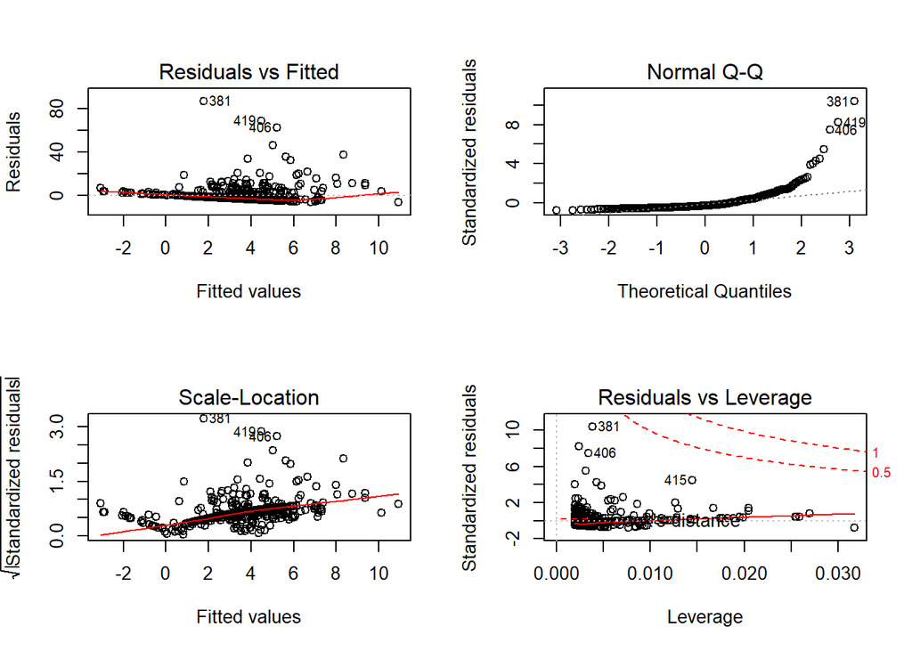

```r
par(mfrow = c(2, 2))
plot(fit7)
```

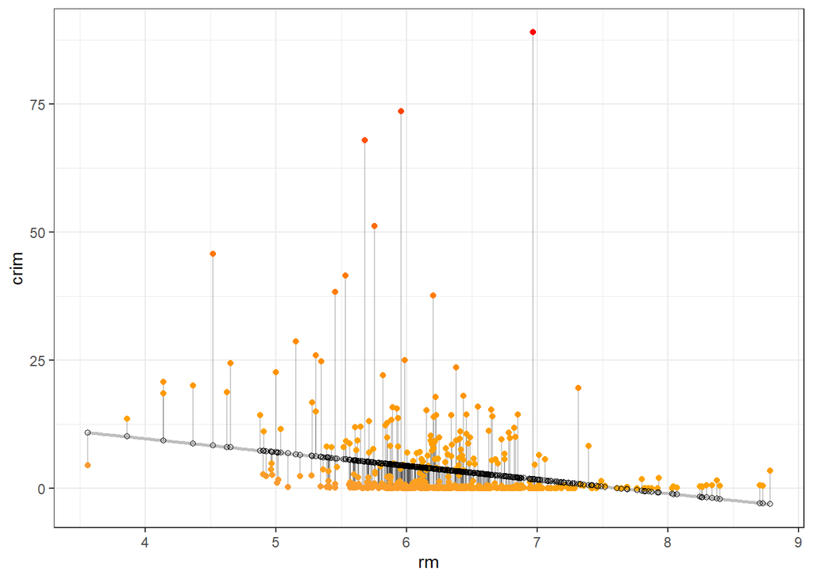

```r
dataset$predicted <- predict(fit7)
dataset$residuals <- residuals(fit7)
ggplot(dataset, aes(x = rm, y = crim)) +
  geom_smooth(method = "lm", se = FALSE, color = "grey") +
  geom_segment(aes(xend = rm, yend = predicted), alpha = .2) +
  geom_point(aes(color = residuals)) +
  scale_color_gradient2(low = "blue", mid = "orange", high = "red") +
  guides(color = FALSE) +
  geom_point(aes(y = predicted), shape = 1) +
  theme_bw()
```

```r
fit8 <- lm(crim ~ dis, data = dataset)
summary(fit8)
```

```
##
## Call:
## lm(formula = crim ~ dis, data = dataset)
##
## Residuals:
##    Min     1Q Median     3Q    Max
## -6.708 -4.134 -1.527  1.516 81.674
##
## Coefficients:
##             Estimate Std. Error t value Pr(>|t|)
## (Intercept)   9.4993     0.7304  13.006   <2e-16 ***
## dis          -1.5509     0.1683  -9.213   <2e-16 ***
## ---
## Signif. codes:  0 '***' 0.001 '**' 0.01 '*' 0.05 '.' 0.1 ' ' 1
##
## Residual standard error: 7.965 on 504 degrees of freedom
## Multiple R-squared:  0.1441, Adjusted R-squared:  0.1425
## F-statistic: 84.89 on 1 and 504 DF,  p-value: < 2.2e-16
```

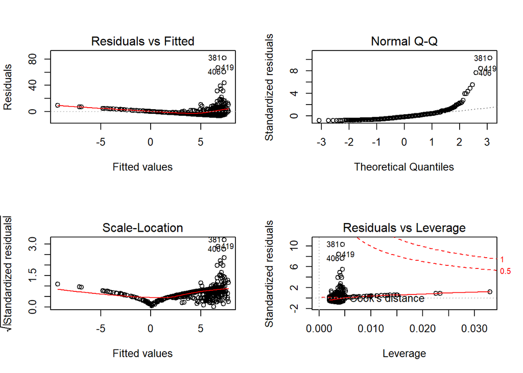

```r
par(mfrow = c(2, 2))
plot(fit8)
```

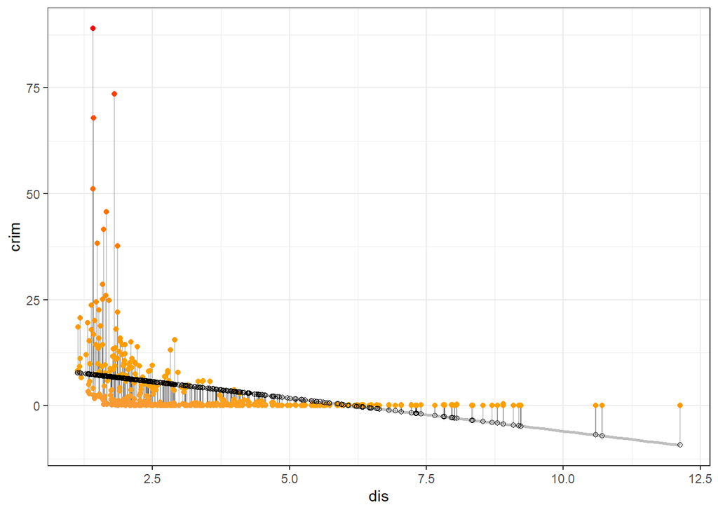

```r
dataset$predicted <- predict(fit8)
dataset$residuals <- residuals(fit8)
ggplot(dataset, aes(x = dis, y = crim)) +
  geom_smooth(method = "lm", se = FALSE, color = "grey") +
  geom_segment(aes(xend = dis, yend = predicted), alpha = .2) +
  geom_point(aes(color = residuals)) +
  scale_color_gradient2(low = "blue", mid = "orange", high = "red") +
  guides(color = FALSE) +
  geom_point(aes(y = predicted), shape = 1) +
  theme_bw()
```

```r
fit9 <- lm(crim ~ tax, data = dataset)
summary(fit9)
```

```
##
## Call:
## lm(formula = crim ~ tax, data = dataset)
##
## Residuals:
##     Min      1Q  Median      3Q     Max
## -12.513  -2.738  -0.194   1.065  77.696
##
## Coefficients:
##              Estimate Std. Error t value Pr(>|t|)
## (Intercept) -8.528369   0.815809  -10.45   <2e-16 ***
## tax          0.029742   0.001847   16.10   <2e-16 ***
## ---
## Signif. codes:  0 '***' 0.001 '**' 0.01 '*' 0.05 '.' 0.1 ' ' 1
##
## Residual standard error: 6.997 on 504 degrees of freedom
## Multiple R-squared:  0.3396, Adjusted R-squared:  0.3383
## F-statistic: 259.2 on 1 and 504 DF,  p-value: < 2.2e-16
```

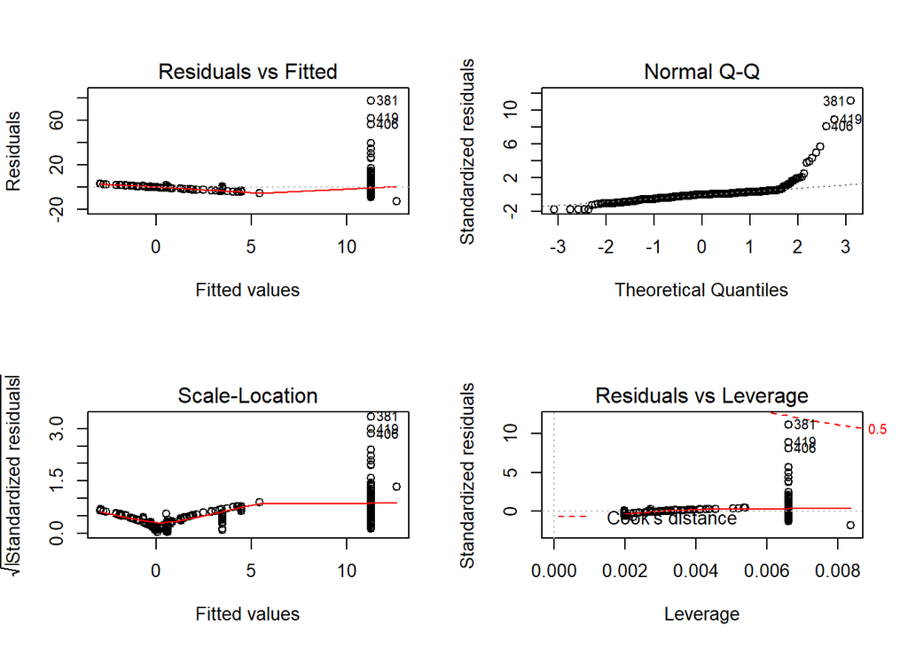

```r
par(mfrow = c(2, 2))
plot(fit9)
```

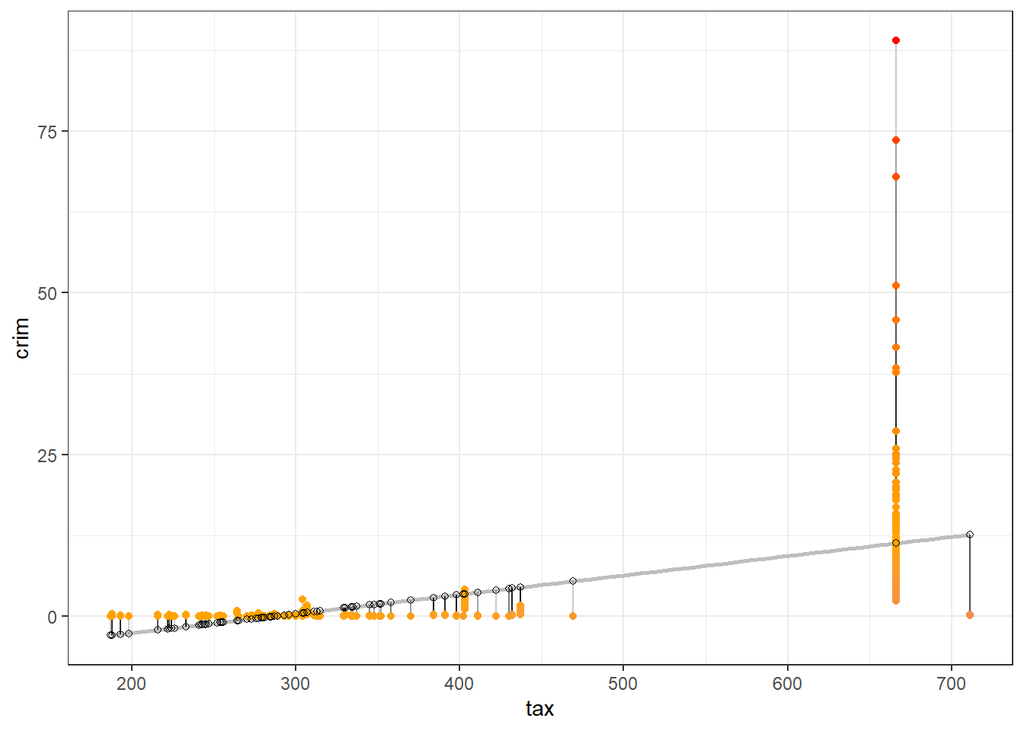

```r
dataset$predicted <- predict(fit9)
dataset$residuals <- residuals(fit9)
ggplot(dataset, aes(x = tax, y = crim)) +
  geom_smooth(method = "lm", se = FALSE, color = "grey") +
  geom_segment(aes(xend = tax, yend = predicted), alpha = .2) +
  geom_point(aes(color = residuals)) +
  scale_color_gradient2(low = "blue", mid = "orange", high = "red") +
  guides(color = FALSE) +
  geom_point(aes(y = predicted), shape = 1) +
  theme_bw()
```

```r
fit10 <- lm(crim ~ ptratio, data = dataset)
summary(fit10)
```

```
##
## Call:
## lm(formula = crim ~ ptratio, data = dataset)
##
## Residuals:
##    Min     1Q Median     3Q    Max
## -7.654 -3.985 -1.912  1.825 83.353
##
## Coefficients:
##             Estimate Std. Error t value Pr(>|t|)
## (Intercept) -17.6469     3.1473  -5.607 3.40e-08 ***
## ptratio       1.1520     0.1694   6.801 2.94e-11 ***
## ---
## Signif. codes:  0 '***' 0.001 '**' 0.01 '*' 0.05 '.' 0.1 ' ' 1
##
## Residual standard error: 8.24 on 504 degrees of freedom
## Multiple R-squared:  0.08407,    Adjusted R-squared:  0.08225
## F-statistic: 46.26 on 1 and 504 DF,  p-value: 2.943e-11
```

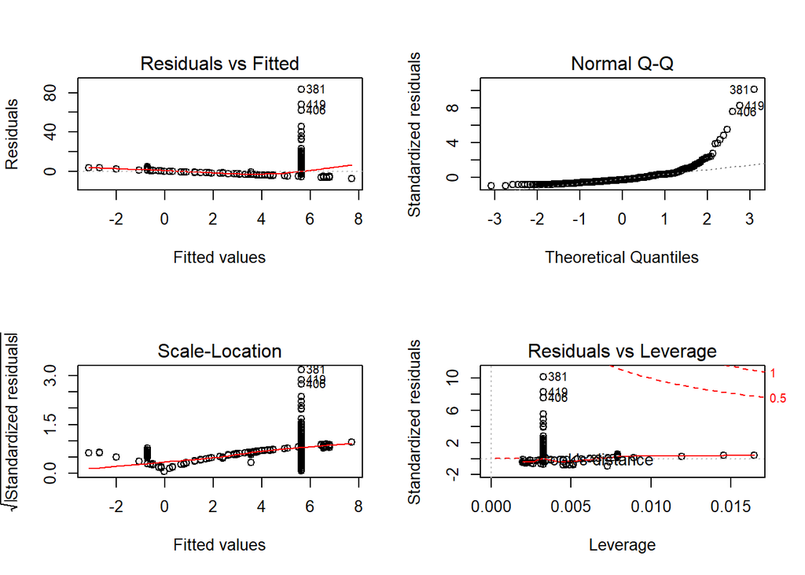

```r
par(mfrow = c(2, 2))
plot(fit10)
```

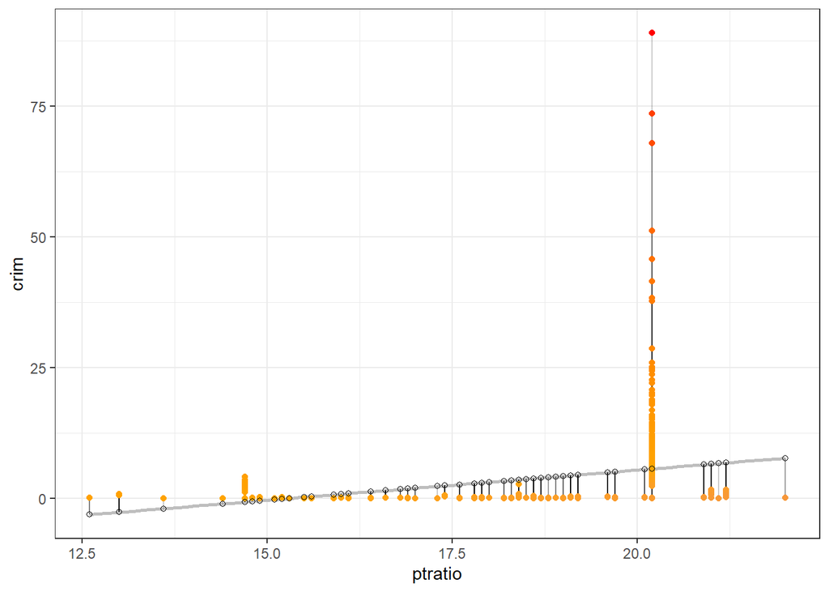

```r
dataset$predicted <- predict(fit10)
dataset$residuals <- residuals(fit10)
ggplot(dataset, aes(x = ptratio, y = crim)) +
  geom_smooth(method = "lm", se = FALSE, color = "grey") +
  geom_segment(aes(xend = ptratio, yend = predicted), alpha = .2) +
  geom_point(aes(color = residuals)) +
  scale_color_gradient2(low = "blue", mid = "orange", high = "red") +
  guides(color = FALSE) +
  geom_point(aes(y = predicted), shape = 1) +
  theme_bw()
```

```r
fit11 <- lm(crim ~ black, data = dataset)
summary(fit11)
```

```
##
## Call:
## lm(formula = crim ~ black, data = dataset)
##
## Residuals:
##     Min      1Q  Median      3Q     Max
## -13.756  -2.299  -2.095  -1.296  86.822
##
## Coefficients:
##              Estimate Std. Error t value Pr(>|t|)
## (Intercept) 16.553530   1.425903  11.609   <2e-16 ***
## black       -0.036280   0.003873  -9.367   <2e-16 ***
## ---
## Signif. codes:  0 '***' 0.001 '**' 0.01 '*' 0.05 '.' 0.1 ' ' 1
##
## Residual standard error: 7.946 on 504 degrees of freedom
## Multiple R-squared:  0.1483, Adjusted R-squared:  0.1466
## F-statistic: 87.74 on 1 and 504 DF,  p-value: < 2.2e-16
```

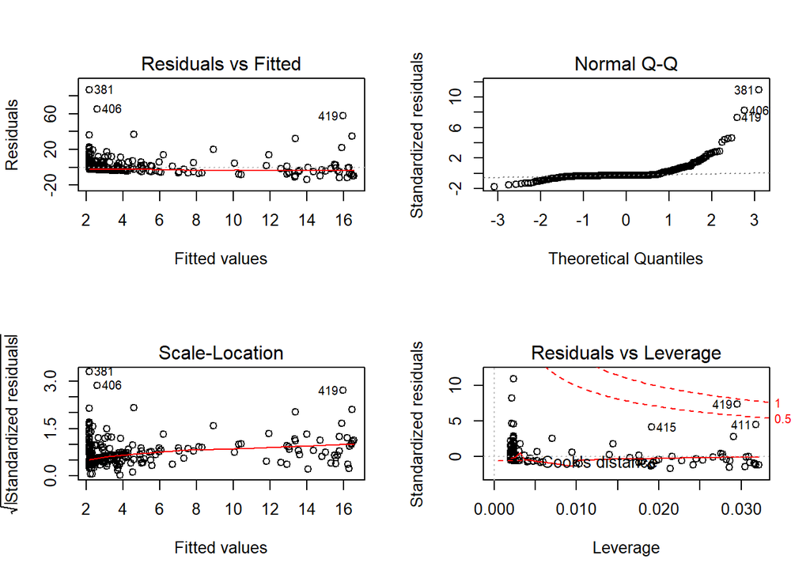

```r
par(mfrow = c(2, 2))
plot(fit11)
```

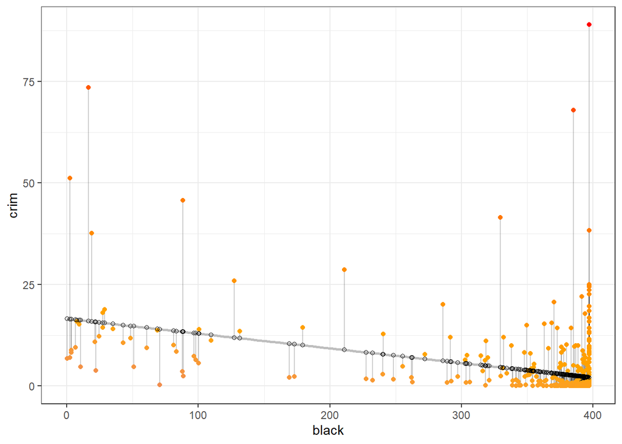

```r
dataset$predicted <- predict(fit11)
dataset$residuals <- residuals(fit11)
ggplot(dataset, aes(x = black, y = crim)) +
  geom_smooth(method = "lm", se = FALSE, color = "grey") +
  geom_segment(aes(xend = black, yend = predicted), alpha = .2) +
  geom_point(aes(color = residuals)) +
  scale_color_gradient2(low = "blue", mid = "orange", high = "red") +
  guides(color = FALSE) +
  geom_point(aes(y = predicted), shape = 1) +
  theme_bw()
```

```r
fit12 <- lm(crim ~ lstat, data = dataset)
summary(fit12)
```

```
##
## Call:
## lm(formula = crim ~ lstat, data = dataset)
##
## Residuals:
##     Min      1Q  Median      3Q     Max
## -13.925  -2.822  -0.664   1.079  82.862
##
## Coefficients:
##             Estimate Std. Error t value Pr(>|t|)
## (Intercept) -3.33054    0.69376  -4.801 2.09e-06 ***
## lstat        0.54880    0.04776  11.491  < 2e-16 ***
## ---
## Signif. codes:  0 '***' 0.001 '**' 0.01 '*' 0.05 '.' 0.1 ' ' 1
##
## Residual standard error: 7.664 on 504 degrees of freedom
## Multiple R-squared:  0.2076, Adjusted R-squared:  0.206
## F-statistic:   132 on 1 and 504 DF,  p-value: < 2.2e-16
```

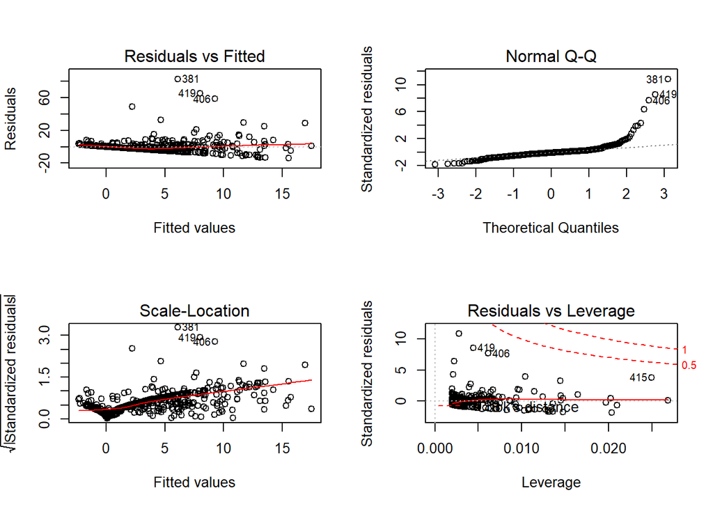

```r
par(mfrow = c(2, 2))
plot(fit12)
```

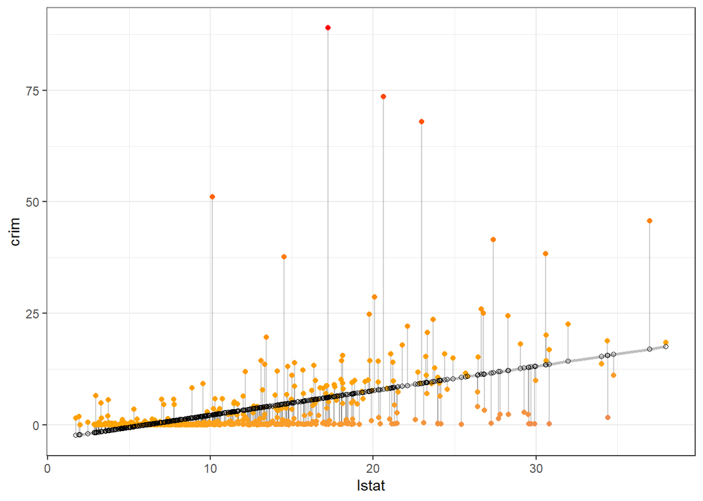

```r
dataset$predicted <- predict(fit12)
dataset$residuals <- residuals(fit12)
ggplot(dataset, aes(x = lstat, y = crim)) +
  geom_smooth(method = "lm", se = FALSE, color = "grey") +
  geom_segment(aes(xend = lstat, yend = predicted), alpha = .2) +
  geom_point(aes(color = residuals)) +
  scale_color_gradient2(low = "blue", mid = "orange", high = "red") +
  guides(color = FALSE) +
  geom_point(aes(y = predicted), shape = 1) +
  theme_bw()
```

```r
fit13 <- lm(crim ~ medv, data = dataset)
summary(fit13)
```

```
##
## Call:
## lm(formula = crim ~ medv, data = dataset)
##
## Residuals:
##    Min     1Q Median     3Q    Max
## -9.071 -4.022 -2.343  1.298 80.957
##
## Coefficients:
##             Estimate Std. Error t value Pr(>|t|)
## (Intercept) 11.79654    0.93419   12.63   <2e-16 ***
## medv        -0.36316    0.03839   -9.46   <2e-16 ***
## ---
## Signif. codes:  0 '***' 0.001 '**' 0.01 '*' 0.05 '.' 0.1 ' ' 1
##
## Residual standard error: 7.934 on 504 degrees of freedom
## Multiple R-squared:  0.1508, Adjusted R-squared:  0.1491
## F-statistic: 89.49 on 1 and 504 DF,  p-value: < 2.2e-16
```

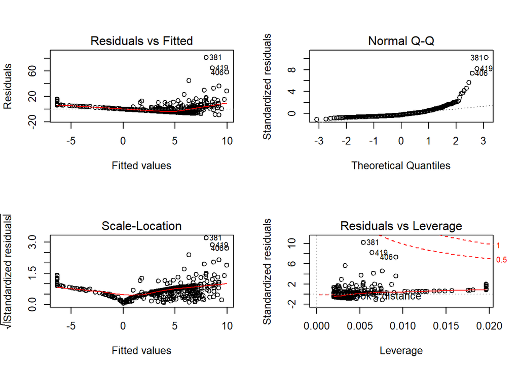

```r
par(mfrow = c(2, 2))
plot(fit13)
```

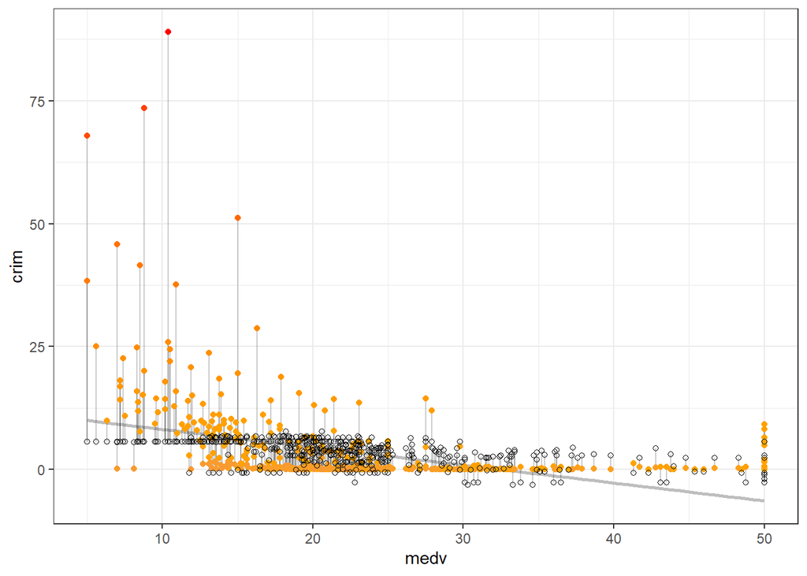

```r
dataset$predicted <- predict(fit10)
dataset$residuals <- residuals(fit10)
ggplot(dataset, aes(x = medv, y = crim)) +
  geom_smooth(method = "lm", se = FALSE, color = "grey") +
  geom_segment(aes(xend = medv, yend = predicted), alpha = .2) +
  geom_point(aes(color = residuals)) +
  scale_color_gradient2(low = "blue", mid = "orange", high = "red") +
  guides(color = FALSE) +
  geom_point(aes(y = predicted), shape = 1) +
  theme_bw()
```